# H3: Comparación entre proyectos

Sección 5.5: presencia del repertorio de mercado y transversalidad de la necesidad y la igualdad, PGU frente al sistema mixto

Este reporte respalda la sección 5.5 del manuscrito. H3 sostiene que los conceptos relacionados con la justicia de mercado y la capitalización individual tendrán mayor presencia en el debate de la Ley 21.735 que en los debates de la PGU, y que en estos últimos la necesidad material y la igualdad o el universalismo alcanzarán un apoyo más transversal entre grupos políticos.

Las leyes 21.419 y 21.538 se agrupan como debates de la PGU. El repertorio de mercado son los siete conceptos que H1 atribuye a la derecha: propiedad de los fondos, capitalización individual, reciprocidad contributiva, libertad de elección, conciencia de costos, ineficiencia y riesgo estatal y previsión como mercado.

## Seteo de la sesión

**Código**

```r
pacman::p_load(arrow, dplyr, tidyr, purrr, stringr, ggplot2, scales, lme4,
               parallel)
source("R/analysis_base.R")
source("R/apa7_word_table.R")

TABLE_DIR <- "output/tables/resultados"
FIGURE_DIR <- "output/figures/resultados"
dir.create(TABLE_DIR, recursive = TRUE, showWarnings = FALSE)
dir.create(FIGURE_DIR, recursive = TRUE, showWarnings = FALSE)
SEED <- 20261022
N_BOOT <- 1000L
N_CORES <- max(1L, detectCores() - 1L)
knitr::opts_chunk$set(cache.extra = list(tools::md5sum(c(
  "R/analysis_base.R",
  file.path(LUNA_RUN_DIR, c("annotations.parquet", "results.parquet")),
  sprintf("data/proc_data/ley_%s/coding_chunks_long.parquet", names(LAW_LABELS)),
  Sys.glob(file.path(STANCE_ADJUDICATION_DIR, "*", "decisions", "*.json")))),
  SEED, N_BOOT))

MARKET <- c("propiedad_individual_fondos", "capitalizacion_individual",
            "reciprocidad_contributiva", "libertad_eleccion_previsional",
            "conciencia_costos", "ineficiencia_estado", "prevision_como_mercado")
TRANSVERSAL <- c("necesidad_material", "igualdad_universalismo")
DEBATE_COLORS <- c(PGU = "#8c8c8c", `Sistema mixto` = "#2f6fa3")
BLOC_COLORS <- c(Izquierda = "#b03a7a", Derecha = "#12866f")
theme_set(theme_minimal(base_size = 11) +
            theme(panel.grid.minor = element_blank(),
                  panel.grid.major.y = element_blank()))
pct <- \(x) label_percent(accuracy = 1, suffix = " %")(x)
```

## Datos

La unidad es la intervención sustantiva. Actitud se omite del universo de conceptos por tener solo dos declaraciones en el corpus.

**Código**

```r
key <- c("law_number", "document_uri", "utterance_id")
base <- load_analysis_base(LUNA_RUN_DIR)
interventions <- base$interventions |>
  filter(substantive) |>
  mutate(debate = factor(if_else(debate == "PGU", "PGU", "Sistema mixto"),
                         levels = names(DEBATE_COLORS)),
         row = row_number())
concepts <- setdiff(sort(unique(base$claims$concept_id)), "actitud")
stopifnot(all(c(MARKET, TRANSVERSAL) %in% concepts))
claims <- base$claims |>
  filter(concept_id %in% concepts) |>
  inner_join(interventions |> select(all_of(key), row), by = key)
# Matrices intervención × concepto: apoyo, rechazo y presencia (cualquier postura).
indicator <- function(s) {
  m <- matrix(0L, nrow(interventions), length(concepts), dimnames = list(NULL, concepts))
  r <- if (is.null(s)) distinct(claims, row, concept_id) else filter(claims, stance == s)
  m[cbind(r$row, match(r$concept_id, concepts))] <- 1L
  m
}
SUP <- indicator("support")
OPP <- indicator("oppose")
PRES <- indicator(NULL)
stopifnot(all(PRES == pmax(SUP, OPP)))
interventions |>
  group_by(debate) |>
  summarise(intervenciones = n(), actores = n_distinct(speaker_id)) |>
  knitr::kable()
```

| debate | intervenciones | actores |
| --- | --- | --- |
| PGU | 182 | 111 |
| Sistema mixto | 358 | 187 |

## (a) Presencia del repertorio de mercado

La presencia de un concepto es la proporción de intervenciones que lo mencionan, con apoyo o con rechazo (suplemento, sección 4.2). Para mostrar de dónde viene cada cambio, la presencia se descompone en intervenciones que solo lo apoyan, que solo lo rechazan o que hacen ambas cosas.

Los intervalos del 95 % provienen de 1000 remuestreos de actores dentro de cada debate: se sortean actores con reposición, se conservan todas sus intervenciones y se recalculan las proporciones.

**Código**

```r
# Presencia de cada concepto en un conjunto de intervenciones, total y por postura.
presence_measures <- function(rows) {
  pres <- PRES[rows, , drop = FALSE]
  sup <- SUP[rows, , drop = FALSE]
  opp <- OPP[rows, , drop = FALSE]
  tibble(concept_id = concepts,
         presencia = colMeans(pres),
         solo_apoyo = colMeans(sup * (1 - opp)),
         solo_rechazo = colMeans(opp * (1 - sup)),
         ambas = colMeans(sup * opp))
}
# Remuestrea actores dentro del debate y conserva todas sus intervenciones.
presence_boot <- function(rows, seed) {
  set.seed(seed)
  by_actor <- split(rows, interventions$speaker_id[rows])
  map_dfr(seq_len(N_BOOT), \(i) {
    sampled <- sample(length(by_actor), replace = TRUE)
    presence_measures(unlist(by_actor[sampled], use.names = FALSE)) |>
      select(concept_id, presencia) |>
      mutate(replica = i)
  })
}
```

**Código**

```r
debate_rows <- split(seq_len(nrow(interventions)), interventions$debate)
presence_point <- imap_dfr(debate_rows, \(rows, d) presence_measures(rows) |> mutate(debate = d))
presence_reps <- imap_dfr(debate_rows, \(rows, d)
                          presence_boot(rows, SEED + match(d, names(debate_rows))) |>
                            mutate(debate = d))
```

**Código**

```r
ci <- \(x) tibble(conf.low = quantile(x, 0.025), conf.high = quantile(x, 0.975))
presence_ci <- presence_reps |>
  pivot_longer(presencia, names_to = "medida") |>
  group_by(debate, concept_id, medida) |>
  reframe(ci(value))
presence_diff <- presence_reps |>
  pivot_longer(presencia, names_to = "medida") |>
  pivot_wider(names_from = debate, values_from = value) |>
  mutate(diferencia = `Sistema mixto` - PGU) |>
  group_by(concept_id, medida) |>
  reframe(ci(diferencia)) |>
  left_join(presence_point |>
              pivot_longer(presencia, names_to = "medida") |>
              select(debate, concept_id, medida, value) |>
              pivot_wider(names_from = debate, values_from = value) |>
              mutate(estimate = `Sistema mixto` - PGU),
            by = c("concept_id", "medida")) |>
  mutate(concepto = unname(CONCEPT_SHORT[concept_id]),
         mercado = concept_id %in% MARKET)
presence_table <- presence_point |>
  pivot_longer(presencia, names_to = "medida", values_to = "estimate") |>
  left_join(presence_ci, by = c("debate", "concept_id", "medida")) |>
  mutate(concepto = unname(CONCEPT_SHORT[concept_id]), mercado = concept_id %in% MARKET)
write_parquet(presence_table, file.path(TABLE_DIR, "h3_presencia.parquet"))
write_parquet(presence_diff, file.path(TABLE_DIR, "h3_presencia_diferencias.parquet"))

presence_diff |>
  filter(mercado) |>
  transmute(concepto, medida, PGU = 100 * PGU, `Sistema mixto` = 100 * `Sistema mixto`,
            diferencia = 100 * estimate, ic_inf = 100 * conf.low, ic_sup = 100 * conf.high) |>
  arrange(medida, desc(diferencia)) |>
  knitr::kable(digits = 1, caption = "Repertorio de mercado: presencia (%) y diferencia sistema mixto − PGU (pp)")
```

Repertorio de mercado: presencia (%) y diferencia sistema mixto − PGU (pp)

| concepto | medida | PGU | Sistema mixto | diferencia | ic_inf | ic_sup |
| --- | --- | --- | --- | --- | --- | --- |
| Previsión como mercado | presencia | 15.4 | 53.4 | 38.0 | 29.9 | 45.6 |
| Propiedad de los fondos | presencia | 3.3 | 29.9 | 26.6 | 20.6 | 32.6 |
| Ineficiencia y riesgo estatal | presencia | 0.5 | 24.3 | 23.8 | 19.0 | 28.7 |
| Capitalización individual | presencia | 8.8 | 29.1 | 20.3 | 14.0 | 26.8 |
| Reciprocidad contributiva | presencia | 19.8 | 34.9 | 15.1 | 7.3 | 22.9 |
| Libertad de elección | presencia | 2.7 | 15.9 | 13.2 | 8.5 | 17.9 |
| Conciencia de costos | presencia | 23.6 | 20.4 | -3.2 | -11.0 | 4.7 |

**Código**

```r
presence_point |>
  filter(concept_id %in% MARKET) |>
  transmute(concepto = CONCEPT_SHORT[concept_id], debate,
            across(c(presencia, solo_apoyo, solo_rechazo, ambas), \(x) 100 * x)) |>
  knitr::kable(digits = 1, caption = "Descomposición de la presencia por postura (%)")
```

Descomposición de la presencia por postura (%)

| concepto | debate | presencia | solo_apoyo | solo_rechazo | ambas |
| --- | --- | --- | --- | --- | --- |
| Capitalización individual | PGU | 8.8 | 2.7 | 6.0 | 0.0 |
| Conciencia de costos | PGU | 23.6 | 11.5 | 10.4 | 1.6 |
| Ineficiencia y riesgo estatal | PGU | 0.5 | 0.0 | 0.5 | 0.0 |
| Libertad de elección | PGU | 2.7 | 2.7 | 0.0 | 0.0 |
| Previsión como mercado | PGU | 15.4 | 8.2 | 6.6 | 0.5 |
| Propiedad de los fondos | PGU | 3.3 | 2.7 | 0.5 | 0.0 |
| Reciprocidad contributiva | PGU | 19.8 | 19.8 | 0.0 | 0.0 |
| Capitalización individual | Sistema mixto | 29.1 | 16.2 | 12.8 | 0.0 |
| Conciencia de costos | Sistema mixto | 20.4 | 13.4 | 5.0 | 2.0 |
| Ineficiencia y riesgo estatal | Sistema mixto | 24.3 | 16.5 | 7.3 | 0.6 |
| Libertad de elección | Sistema mixto | 15.9 | 15.4 | 0.3 | 0.3 |
| Previsión como mercado | Sistema mixto | 53.4 | 21.8 | 24.3 | 7.3 |
| Propiedad de los fondos | Sistema mixto | 29.9 | 27.9 | 2.0 | 0.0 |
| Reciprocidad contributiva | Sistema mixto | 34.9 | 34.9 | 0.0 | 0.0 |

**Código**

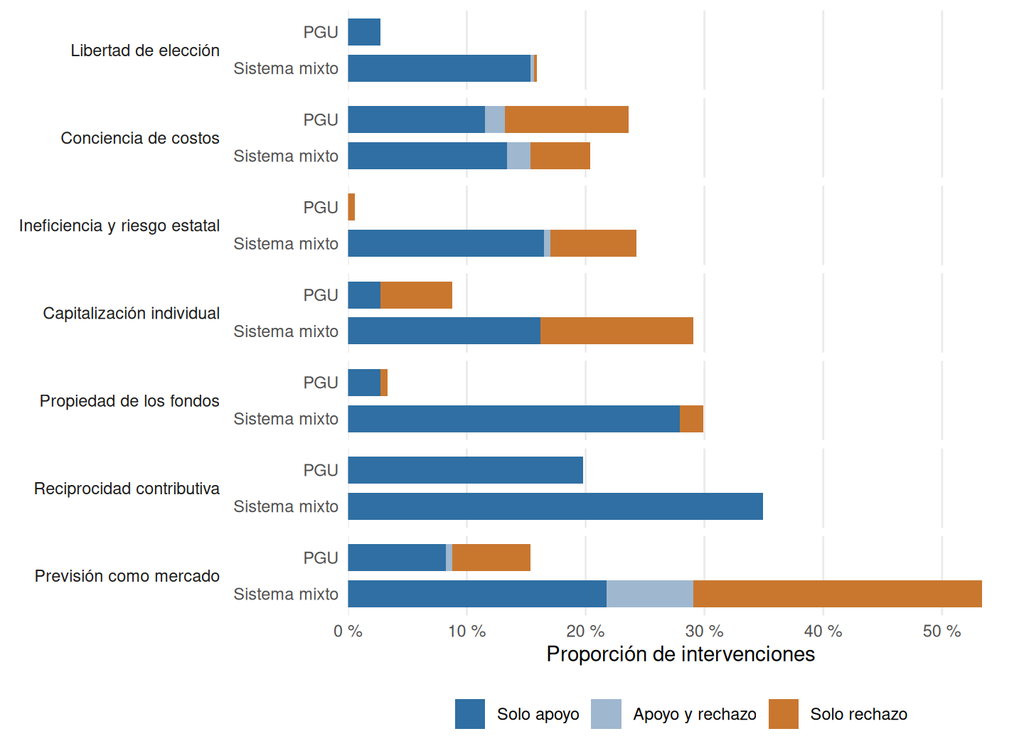

Figura 1: Presencia de los conceptos del repertorio de mercado por postura, PGU y sistema mixto

```r
market_order <- presence_point |>
  filter(debate == "Sistema mixto", concept_id %in% MARKET) |>
  arrange(presencia) |>
  pull(concept_id)
bars <- presence_point |>
  filter(concept_id %in% MARKET) |>
  pivot_longer(c(solo_apoyo, ambas, solo_rechazo), names_to = "postura", values_to = "valor") |>
  mutate(postura = factor(recode(postura, solo_apoyo = "Solo apoyo", ambas = "Apoyo y rechazo",
                                 solo_rechazo = "Solo rechazo"),
                          levels = c("Solo rechazo", "Apoyo y rechazo", "Solo apoyo")),
         concepto = factor(CONCEPT_SHORT[concept_id], levels = CONCEPT_SHORT[market_order]),
         debate = factor(debate, levels = rev(names(DEBATE_COLORS))))
panel_presence <- ggplot(bars, aes(x = valor, y = debate, fill = postura)) +
  geom_col(width = 0.75) +
  facet_grid(concepto ~ ., switch = "y") +
  scale_x_continuous(labels = pct, expand = expansion(mult = c(0, 0.05))) +
  scale_fill_manual(values = c(`Solo apoyo` = "#2f6fa3", `Apoyo y rechazo` = "#9fb7cf",
                               `Solo rechazo` = "#c9772f"),
                    breaks = c("Solo apoyo", "Apoyo y rechazo", "Solo rechazo")) +
  labs(x = "Proporción de intervenciones", y = NULL, fill = NULL) +
  theme(strip.placement = "outside", strip.text.y.left = element_text(angle = 0, hjust = 1),
        legend.position = "bottom", panel.spacing.y = unit(0.3, "lines"))
fig_market <- panel_presence
print(fig_market)
ggsave(file.path(FIGURE_DIR, "figura9_h3_mercado.png"), fig_market,
       width = 7.5, height = 5.5, dpi = 300, bg = "white")
```

## (b) Transversalidad de la necesidad material y la igualdad

**Código**

```r
model_data <- interventions |>
  filter(alignment %in% c("izquierda", "derecha")) |>
  mutate(bloque = factor(str_to_title(alignment), levels = names(BLOC_COLORS)),
         genero = factor(gender, levels = c("hombre", "mujer")),
         log_palabras = as.numeric(scale(log(utterance_words))),
         necesidad_material = SUP[row, "necesidad_material"],
         igualdad_universalismo = SUP[row, "igualdad_universalismo"])
model_data |>
  count(debate, bloque) |>
  pivot_wider(names_from = bloque, values_from = n) |>
  knitr::kable(caption = "Intervenciones por debate y bloque")
```

Intervenciones por debate y bloque

| debate | Izquierda | Derecha |
| --- | --- | --- |
| PGU | 74 | 79 |
| Sistema mixto | 174 | 145 |

**Código**

```r
model_data |>
  group_by(debate, bloque) |>
  summarise(across(all_of(TRANSVERSAL), mean), .groups = "drop") |>
  knitr::kable(digits = 2, caption = "Proporción observada de intervenciones que apoyan cada concepto")
```

Proporción observada de intervenciones que apoyan cada concepto

| debate | bloque | necesidad_material | igualdad_universalismo |
| --- | --- | --- | --- |
| PGU | Izquierda | 0.51 | 0.50 |
| PGU | Derecha | 0.54 | 0.33 |
| Sistema mixto | Izquierda | 0.62 | 0.33 |
| Sistema mixto | Derecha | 0.30 | 0.26 |

**Código**

```r
control <- glmerControl(optimizer = "bobyqa", optCtrl = list(maxfun = 1e5))
fit_transversal <- function(data, y) {
  glmer(as.formula(paste(y, "~ bloque * debate + genero + log_palabras + (1 | speaker_id)")),
        data = data, family = binomial, control = control)
}
predict_transversal <- function(m, data) {
  grid <- tidyr::crossing(bloque = levels(data$bloque), debate = levels(data$debate))
  pmap_dfr(grid, \(bloque, debate) {
    b <- bloque
    d <- debate
    nd <- mutate(data, bloque = factor(b, levels = levels(data$bloque)),
                 debate = factor(d, levels = levels(data$debate)))
    tibble(bloque = b, debate = d,
           p = mean(predict(m, nd, type = "response", re.form = NA)))
  })
}
gaps <- function(pred) {
  pred |>
    group_by(debate) |>
    summarise(# Con signo para no inflar la brecha con el ruido del remuestreo.
              izq_menos_der = p[bloque == "Izquierda"] - p[bloque == "Derecha"],
              .groups = "drop")
}
# Remuestrea actores dentro de cada bloque, con todas sus intervenciones en ambos debates.
boot_transversal <- function(data, y) {
  actors <- distinct(data, speaker_id, bloque)
  mclapply(seq_len(N_BOOT), \(i) {
    set.seed(SEED + i)
    boot_data <- actors |>
      slice_sample(prop = 1, replace = TRUE, by = bloque) |>
      mutate(boot_id = paste0("a", row_number())) |>
      select(speaker_id, boot_id) |>
      inner_join(data, by = "speaker_id", relationship = "many-to-many") |>
      mutate(speaker_id = boot_id)
    m <- tryCatch(suppressMessages(suppressWarnings(fit_transversal(boot_data, y))),
                  error = \(e) NULL)
    if (is.null(m)) return(NULL)
    predict_transversal(m, boot_data) |> mutate(replica = i)
  }, mc.cores = N_CORES) |>
    list_rbind()
}
```

**Código**

```r
models_transversal <- map(set_names(TRANSVERSAL), \(y) fit_transversal(model_data, y))
boot_reps <- map(set_names(TRANSVERSAL), \(y) boot_transversal(model_data, y))
```

**Código**

```r
map_dfr(models_transversal, \(m) tibble(singular = isSingular(m),
                                        avisos = length(m@optinfo$conv$lme4$messages),
                                        de_actor = attr(VarCorr(m)$speaker_id, "stddev")),
        .id = "concepto") |>
  knitr::kable(digits = 2)
```

| concepto | singular | avisos | de_actor |
| --- | --- | --- | --- |
| necesidad_material | FALSE | 0 | 0.76 |
| igualdad_universalismo | FALSE | 0 | 0.51 |

**Código**

```r
pred_transversal <- imap_dfr(models_transversal, \(m, y) {
  point <- predict_transversal(m, model_data)
  reps <- boot_reps[[y]]
  point |>
    left_join(reps |> group_by(bloque, debate) |> reframe(ci(p)), by = c("bloque", "debate")) |>
    mutate(concept_id = y)
})
gap_transversal <- imap_dfr(models_transversal, \(m, y) {
  point <- gaps(predict_transversal(m, model_data)) |>
    pivot_longer(-debate, names_to = "medida", values_to = "estimate")
  reps <- boot_reps[[y]] |>
    group_by(replica) |>
    group_modify(\(d, k) gaps(d)) |>
    ungroup() |>
    pivot_longer(izq_menos_der, names_to = "medida")
  by_debate <- point |>
    left_join(reps |> group_by(debate, medida) |> reframe(ci(value)),
              by = c("debate", "medida"))
  change <- reps |>
    pivot_wider(names_from = debate, values_from = value) |>
    mutate(diferencia = `Sistema mixto` - PGU) |>
    group_by(medida) |>
    reframe(ci(diferencia)) |>
    left_join(point |> pivot_wider(names_from = debate, values_from = estimate) |>
                transmute(medida, estimate = `Sistema mixto` - PGU), by = "medida") |>
    mutate(debate = "Sistema mixto − PGU")
  bind_rows(by_debate, change) |> mutate(concept_id = y)
})
write_parquet(pred_transversal, file.path(TABLE_DIR, "h3_transversalidad_predicciones.parquet"))
write_parquet(gap_transversal, file.path(TABLE_DIR, "h3_transversalidad_brechas.parquet"))
cat("Réplicas completadas:", map_int(boot_reps, \(r) n_distinct(r$replica)), "\n")
```

```
Réplicas completadas: 1000 1000
```

**Código**

```r
pred_transversal |>
  transmute(concepto = CONCEPT_SHORT[concept_id], debate, bloque,
            p = 100 * p, ic_inf = 100 * conf.low, ic_sup = 100 * conf.high) |>
  knitr::kable(digits = 1, caption = "Probabilidad predicha de apoyo (%)")
```

Probabilidad predicha de apoyo (%)

| concepto | debate | bloque | p | ic_inf | ic_sup |
| --- | --- | --- | --- | --- | --- |
| Necesidad material | PGU | Derecha | 53.9 | 42.6 | 65.3 |
| Necesidad material | Sistema mixto | Derecha | 29.8 | 21.2 | 38.9 |
| Necesidad material | PGU | Izquierda | 52.6 | 39.5 | 67.1 |
| Necesidad material | Sistema mixto | Izquierda | 65.3 | 56.4 | 74.1 |
| Igualdad y universalismo | PGU | Derecha | 32.2 | 19.6 | 45.2 |
| Igualdad y universalismo | Sistema mixto | Derecha | 26.6 | 18.9 | 34.5 |
| Igualdad y universalismo | PGU | Izquierda | 49.9 | 38.5 | 61.5 |
| Igualdad y universalismo | Sistema mixto | Izquierda | 31.6 | 24.3 | 39.4 |

**Código**

```r
gap_transversal |>
  transmute(concepto = CONCEPT_SHORT[concept_id], medida, debate,
            brecha = 100 * estimate, ic_inf = 100 * conf.low, ic_sup = 100 * conf.high) |>
  knitr::kable(digits = 1, caption = "Diferencia izquierda − derecha en la probabilidad de apoyo (pp)")
```

Diferencia izquierda − derecha en la probabilidad de apoyo (pp)

| concepto | medida | debate | brecha | ic_inf | ic_sup |
| --- | --- | --- | --- | --- | --- |
| Necesidad material | izq_menos_der | PGU | -1.3 | -17.8 | 16.6 |
| Necesidad material | izq_menos_der | Sistema mixto | 35.5 | 22.6 | 48.4 |
| Necesidad material | izq_menos_der | Sistema mixto − PGU | 36.8 | 15.4 | 56.9 |
| Igualdad y universalismo | izq_menos_der | PGU | 17.7 | 1.7 | 35.3 |
| Igualdad y universalismo | izq_menos_der | Sistema mixto | 5.0 | -5.3 | 15.3 |
| Igualdad y universalismo | izq_menos_der | Sistema mixto − PGU | -12.7 | -31.1 | 6.1 |

**Código**

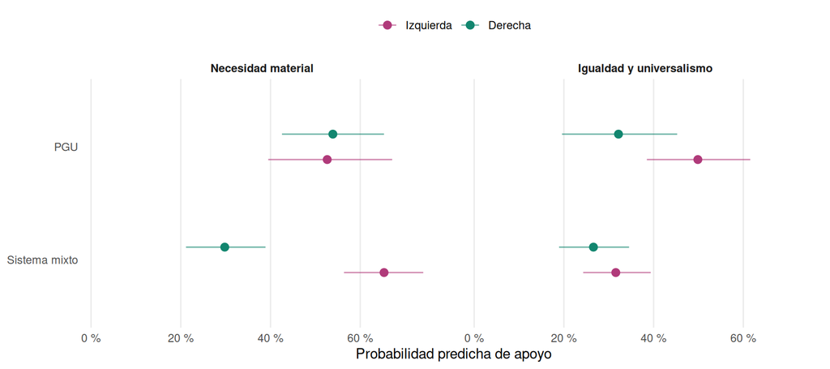

Figura 2: Probabilidad predicha de apoyo a la necesidad material y a la igualdad por bloque político, PGU y sistema mixto

```r
fig_transversal <- pred_transversal |>
  mutate(concepto = factor(CONCEPT_SHORT[concept_id], levels = CONCEPT_SHORT[TRANSVERSAL]),
         debate = factor(debate, levels = rev(names(DEBATE_COLORS))),
         bloque = factor(bloque, levels = names(BLOC_COLORS))) |>
  ggplot(aes(x = p, y = debate)) +
  geom_errorbar(aes(xmin = conf.low, xmax = conf.high, color = bloque), width = 0,
                orientation = "y", linewidth = 0.5, alpha = 0.6,
                position = position_dodge(width = 0.45)) +
  geom_point(aes(color = bloque), size = 2.6, position = position_dodge(width = 0.45)) +
  facet_wrap(~ concepto) +
  scale_x_continuous(labels = pct, limits = c(0, NA), expand = expansion(mult = c(0.02, 0.05))) +
  scale_color_manual(values = BLOC_COLORS) +
  labs(x = "Probabilidad predicha de apoyo", y = NULL, color = NULL) +
  theme(legend.position = "top", strip.text = element_text(face = "bold"),
        panel.spacing.x = unit(1.5, "lines"))
print(fig_transversal)
ggsave(file.path(FIGURE_DIR, "figura10_h3_transversalidad.png"), fig_transversal,
       width = 9, height = 4, dpi = 300, bg = "white")
```

## Tabla para el anexo

Una sola tabla reúne los dos modelos de transversalidad: las probabilidades predichas de apoyo por bloque y debate, la diferencia entre izquierda y derecha en cada debate y su cambio entre debates. Los coeficientes no se reportan; la especificación está en el Anexo 4.

**Código**

```r
dec <- function(x, digits = 1) formatC(round(x, digits) + 0, format = "f", digits = digits, decimal.mark = ",")
ic_txt <- function(est, low, high, digits = 1) {
  paste0(dec(est, digits), " [", dec(low, digits), "; ", dec(high, digits), "]") |>
    str_replace_all("-", "−")
}
pred_wide <- pred_transversal |>
  transmute(concept_id, col = paste(debate, bloque),
            valor = ic_txt(100 * p, 100 * conf.low, 100 * conf.high)) |>
  pivot_wider(names_from = col, values_from = valor)
gap_wide <- gap_transversal |>
  transmute(concept_id, col = paste("dif", debate),
            valor = ic_txt(100 * estimate, 100 * conf.low, 100 * conf.high)) |>
  pivot_wider(names_from = col, values_from = valor)
tabla_h3 <- pred_wide |>
  left_join(gap_wide, by = "concept_id") |>
  transmute(fila = CONCEPT_SHORT[concept_id],
            c1 = `PGU Izquierda`, c2 = `PGU Derecha`, c3 = `dif PGU`,
            c4 = `Sistema mixto Izquierda`, c5 = `Sistema mixto Derecha`,
            c6 = `dif Sistema mixto`, c7 = `dif Sistema mixto − PGU`)
n_interventions <- nobs(models_transversal[[1]])
n_actors <- ngrps(models_transversal[[1]])[["speaker_id"]]
export_apa7_word_table(
  tabla_h3, file.path(TABLE_DIR, "anexo_h3_transversalidad.docx"),
  "Probabilidad predicha de apoyo a la necesidad material y a la igualdad por bloque político, debates de la PGU y del sistema mixto",
  note = paste0(
    "Probabilidad predicha (%) de que una intervención sustantiva apoye el concepto, a ",
    "partir de un modelo logístico multinivel por concepto, e intervalos de confianza del ",
    "95 % entre corchetes, obtenidos con 1.000 remuestreos de actores dentro de cada bloque. ",
    "Δ corresponde a izquierda menos derecha, en puntos porcentuales, y la última columna, a ",
    "su cambio entre el sistema mixto y la PGU. ", n_interventions, " intervenciones de ",
    n_actors, " actores de izquierda y de derecha. La especificación se presenta en el Anexo 4."),
  table_number = 7L, landscape = TRUE, body_font_size = 10,
  header_labels = c("Concepto", "Izquierda", "Derecha", "Δ (pp)", "Izquierda", "Derecha",
                    "Δ (pp)", "Cambio de Δ (pp)"),
  header_groups = c(" " = 1, "PGU" = 3, "Sistema mixto" = 3, " " = 1))
knitr::kable(tabla_h3)
```

| fila | c1 | c2 | c3 | c4 | c5 | c6 | c7 |
| --- | --- | --- | --- | --- | --- | --- | --- |
| Necesidad material | 52,6 [39,5; 67,1] | 53,9 [42,6; 65,3] | −1,3 [−17,8; 16,6] | 65,3 [56,4; 74,1] | 29,8 [21,2; 38,9] | 35,5 [22,6; 48,4] | 36,8 [15,4; 56,9] |
| Igualdad y universalismo | 49,9 [38,5; 61,5] | 32,2 [19,6; 45,2] | 17,7 [1,7; 35,3] | 31,6 [24,3; 39,4] | 26,6 [18,9; 34,5] | 5,0 [−5,3; 15,3] | −12,7 [−31,1; 6,1] |